# code4demo

# File Target

manipulate the voice data.

- In(supported file format)
- Out
- Mono and Stereo
- Play Sound
- summary

# reference

[seewaveIO](https://cran.r-project.org/web/packages/seewave/vignettes/seewave_IO.pdf)

packages require

```r
library(dplyr)
library(tuneR)
library(seewave)
library(audio)
```

## In(supported file format)

seewave 套件整合了 tuneR 與 audio 套件。

支援三種類型的資料格式。

- usual classes: numeric vector, numeric matrix
- time series classes: ts, mts
- sound-specific classes: Wave(tuneR) and audioSample(audio)

## usual classes

### numeric vector

```r
s1 <- sin(2*pi*440*seq(0,1,length.out = 8000))
is.vector(s1)
```

```
## [1] TRUE
```

```r
mode(s1)
```

```
## [1] "numeric"
```

```r
oscillo(wave = s1, f = 8000)
```

[output not shown]

### numeric matrix

單一欄位的 matrix，只要提供取樣頻率(sampling frequency)，依樣可以被視為 sound。

```r
s2 <- as.matrix(s1)
is.matrix(s2)
```

```
## [1] TRUE
```

```r
dim(s2)
```

```
## [1] 8000    1
```

```r
oscillo(wave = s2, f = 8000)
```

[output not shown]

–

如果 matrix 有超過一欄，則只有第一欄會被使用。

```r
x <- rnorm(8000)
s3 <- cbind(s2, x)
s3 %>% head
```

```
##                          x
## [1,] 0.0000000 -0.60239053
## [2,] 0.3387786  0.70197908
## [3,] 0.6374906  0.05330650
## [4,] 0.8608080 -0.31641377
## [5,] 0.9823196  0.55595355
## [6,] 0.9876545  0.02901652
```

```r
is.matrix(s3)
```

```
## [1] TRUE
```

```r
dim(s3)
```

```
## [1] 8000    2
```

```r
oscillo(wave = s3, f = 8000)
```

[output not shown]

## Specific sound classes

For binary wav format or the compressed mps format.

- the class `Wave` object of the package `tuneR`
- the class `audioSample` object of the package `audio`

### Wave class (package tuneR)

Read .wmv data (package tuneR)

```r
s6 <- readWave(filename = "../data/wmv/1kHz_44100Hz_16bit_05sec.wav")
```

read 前兩秒的 聲音，可以用 from, to, units(“sample”, “seconds”, “hours”)做控制。

```r
s7 <- readWave(filename = "../data/wmv/1kHz_44100Hz_16bit_05sec.wav", from = 0, to = 2, units = "seconds")
s7
```

```
##
## Wave Object
##  Number of Samples:      88200
##  Duration (seconds):     2
##  Samplingrate (Hertz):   44100
##  Channels (Mono/Stereo): Mono
##  PCM (integer format):   TRUE
##  Bit (8/16/24/32/64):    16
```

- 取樣頻率為 44100次/每秒。
- 聲音長度為 2秒。
- 取樣點為 44100*2=88200 個數據。
- Mono為單聲道。
- 16 Bit 的解析度。

p.s. 不管是聲音或者是其他信息，只要是經過取樣與量化得到的資料，總稱 PCM data 。「脈衝編碼調變 pulse-code modulation, PCM 」源自訊號學。

–

MP3的檔案也可以讀取。 Read .mp3 data (package tuneR)

```r
mp3 <- readMP3(filename = "../data/mp3/1kHz_44100Hz_16bit_05sec.mp3")
mp3
```

```
##
## Wave Object
##  Number of Samples:      221184
##  Duration (seconds):     5.02
##  Samplingrate (Hertz):   44100
##  Channels (Mono/Stereo): Mono
##  PCM (integer format):   TRUE
##  Bit (8/16/24/32/64):    16
```

–

取出數據與聲音特性。

```r
s7@left %>% head
```

```
## [1]     0  3219  6372  9396 12232 14817
```

```r
s7@right %>% head
```

```
## numeric(0)
```

```r
s7@stereo
```

```
## [1] FALSE
```

```r
s7@samp.rate
```

```
## [1] 44100
```

```r
s7@bit
```

```
## [1] 16
```

```r
s7@pcm
```

```
## [1] TRUE
```

聲音的數值會界在 $\pm2^{bit-1}$

```r
s7@left %>% range()
```

```
## [1] -22670  22670
```

–

### audioSample class (package audio)

- mono: a numeric vector
- stereo: a numeric matrix with two rows

```r
s10 <- load.wave(where = "../data/wmv/1kHz_44100Hz_16bit_05sec.wav")
s10 %>% head
```

```
## sample rate: 44100Hz, mono, 16-bits
## [1] 0.00000000 0.09823608 0.19445801 0.28674316 0.37329102 0.45217896
```

```r
s10$rate
```

```
## [1] 44100
```

```r
s10$bits
```

```
## [1] 16
```

audio 套件有一個好處是可以直接從 R 錄製聲音。  
一共有四個 finctions 可以做操作: record, pause, rewind, resume

```r
s11 <- rep(NA, 16000*5)
t1 <- record(where = s11, rate = 16000, channels = 1)
pause(x = t1)
play(s11)
s11 %>% head
```

下面是一個幫放音訊的小範例。  
更多請看: [audio - Audio Interface for R - RForge.net](http://www.rforge.net/audio/)

```r
a <- play(sin(1:100000/20))
a
# Audio player instance 63b770 of AudioUnits (Mac OS X) driver (macosx).
# Audio player instance 5ff92a90 of Windows MultiMedia audio driver (wmm).
wait(a) # wait for the playback to finish
rewind(a)
resume(a) # play again
```

# Out

## .txt file

可以輸出成 txt file，windows 的用戶還可以跟 Goldwave 軟體介接。

```r
data(tico)
export(wave = tico, f = 22050, header = F)
export(wave = tico, f = 22050, header = T)
export(wave = tico, f = 22050, header = T, filename = "tico4Goldwave.txt")

# 自定義 header
export(wave = tico, f = 22050, header = "f=22050; ch=left", filename = "tico4Goldwave.txt")
```

## .wav file

seewave 使用 tuneR 的 writeWave 為底，儲存的函式為 savewav()

```r
savewav(tico, f = 22050)
```

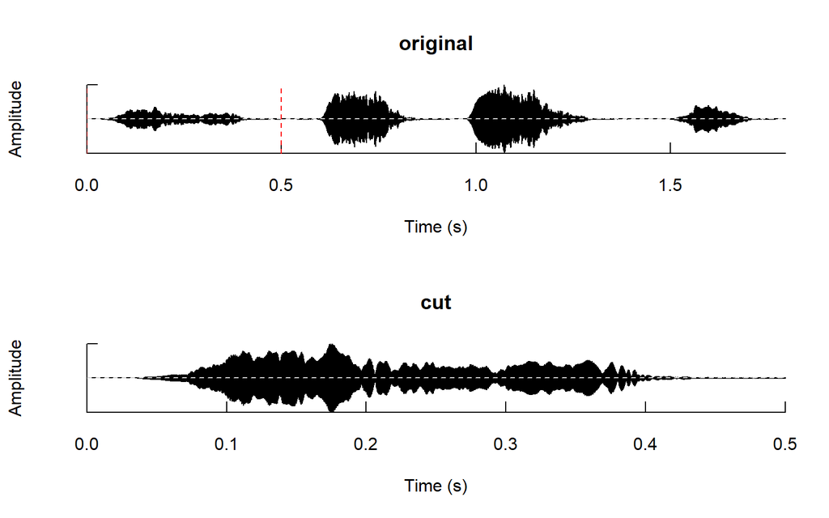

```r
ticofirst <- cutw(wave = tico, f = 22050, from = 0, plot = T, to = 0.5, output = "Wave")
```

```r
savewav(wave = ticofirst, filename = "tico_firstnote.wav")
```

## .flac file

FLAC是一款的音訊壓縮編碼，其特點是可以對音訊檔無失真壓縮。  
不同於其他有損壓縮編碼(如MP3、AAC等)，壓縮後不會有任何音質損失，  
現在已被很多軟體及硬體音訊產品所支援。

要使用的話，電腦必須先安裝 FLAC 的程式。

```r
wav2flac("./tico_firstnote.wav", overwrite = T)
wav2flac("./tico_firstnote.flac", reverse = T)
```

# Mono and Stereo

單聲道與雙聲道。

製造雙聲道聲音

```r
LF <- sine(440)
RI <- sine(2000)
s12 <- stereo(LF, RI)
s12
```

```
##
## Wave Object
##  Number of Samples:      44100
##  Duration (seconds):     1
##  Samplingrate (Hertz):   44100
##  Channels (Mono/Stereo): Stereo
##  PCM (integer format):   FALSE
##  Bit (8/16/24/32/64):    32
```

轉換回單生道

```r
s13 <- mono(s12, "left")
s13@right %>% head
```

```
## numeric(0)
```

```r
s13@left %>% head
```

```
## [1] 0.00000000 0.06264834 0.12505056 0.18696149 0.24813791 0.30833948
```

```r
s14 <- channel(s12, which = "right")
s14@left %>% head
```

```
## [1] 0.0000000 0.2811129 0.5395542 0.7544806 0.9085586 0.9893617
```

```r
s14@left %>% head
```

```
## [1] 0.0000000 0.2811129 0.5395542 0.7544806 0.9085586 0.9893617
```

# Play Sound

```r
play(s1)
# setWavPlayer()
```

```r
listen(s1, f = 8000)
listen(s13)
```

利用系統酯粒呼叫自己享用的撥放器。

```r
system(paste('"C:/Program Files/DAUM/PotPlayer/PotPlayerMini64.exe"', './tico.wav'))
```

# Summary

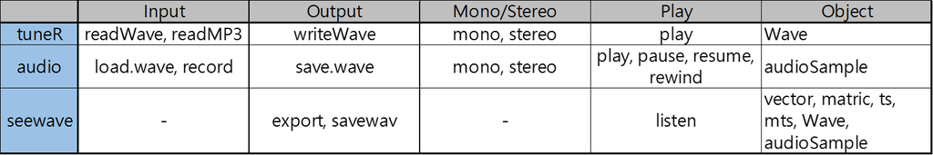

# 小範例01

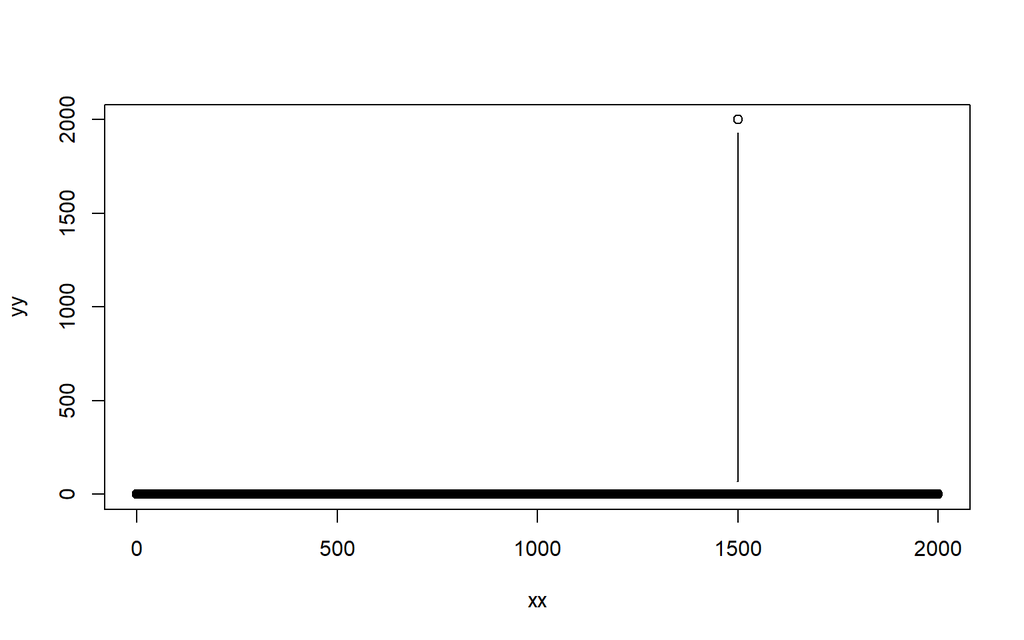

```r
demo_wav <- sine(freq = 1500,
                 samp.rate = 4000,
                 duration = 1,
                 xunit = "time")
demo_fft <- fft(demo_wav@left)
xx <- seq(0, 4000-1/4000, length.out = 4000) %>% head(4000/2)
yy1 <- demo_fft %>% Re; yy2 <- demo_fft %>% Im
yy <- ((yy1**2+yy2**2)**0.5) %>% head(4000/2)
# xx %>% length; yy %>% length #檢查長度。
plot(xx, yy, type = "b")
```

# 小範例02

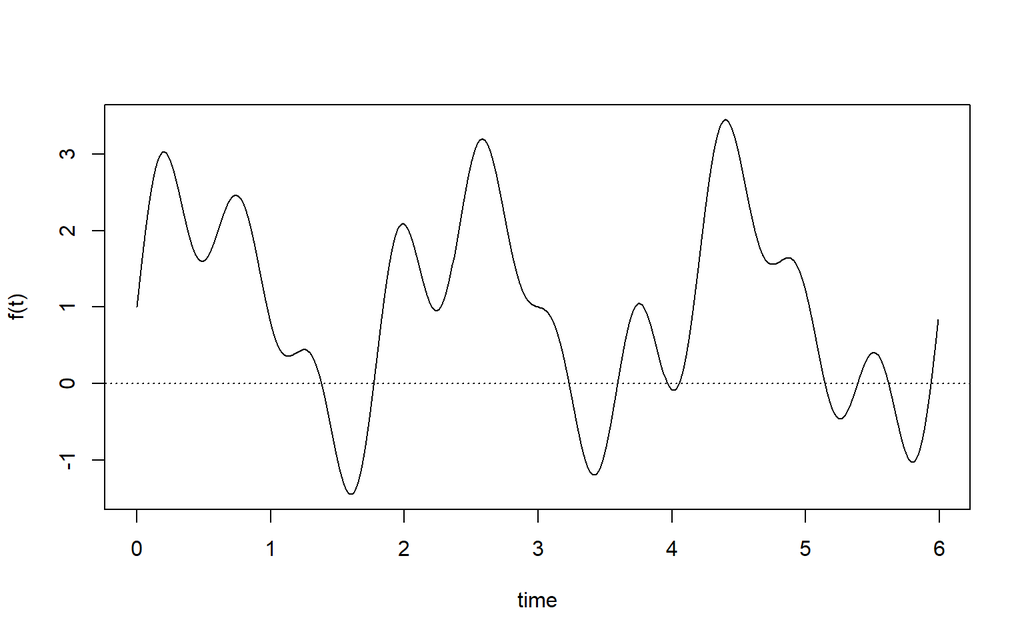

```r
acq.freq <- 100                    # data acquisition (sample) frequency (Hz)
time     <- 6                      # measuring time interval (seconds)
ts       <- seq(0, time-1/acq.freq, 1/acq.freq) # vector of sampling time-points (s)
f.0 <- 1/time

dc.component <- 1
component.freqs <- c(3,7,10)        # frequency of signal components (Hz)
component.delay <- c(0,0,0)         # delay of signal components (radians)
component.strength <- c(1.5,.5,.75) # strength of signal components

f <- function(t,w) {
  dc.component +
  sum( component.strength * sin(component.freqs*w*t + component.delay))
}

plot.fourier <- function(fourier.series, f.0, ts) {
  w <- 2*pi*f.0
  trajectory <- sapply(ts, function(t) fourier.series(t,w))
  plot(ts, trajectory, type="l", xlab="time", ylab="f(t)"); abline(h=0,lty=3)
}
plot.fourier(f,f.0,ts=ts)
```

```r
w <- 2*pi*f.0
trajectory <- sapply(ts, function(t) f(t,w))
head(trajectory,n=30)
```

```
##  [1] 1.000000 1.162132 1.323161 1.481997 1.637568 1.788836 1.934801 2.074515
##  [9] 2.207089 2.331703 2.447610 2.554146 2.650736 2.736896 2.812242 2.876489
## [17] 2.929454 2.971057 3.001324 3.020382 3.028458 3.025877 3.013056 2.990502
## [25] 2.958803 2.918623 2.870694 2.815807 2.754805 2.688575
```

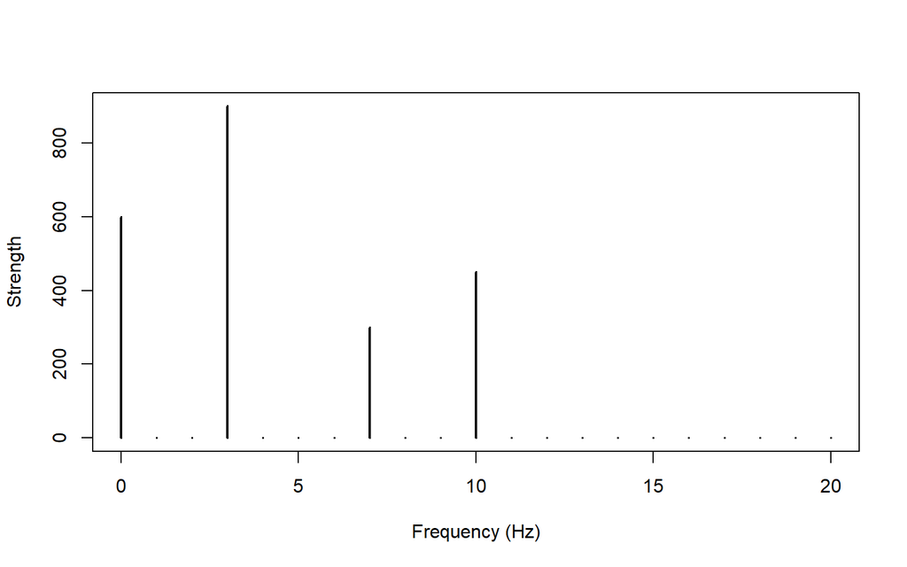

```r
plot.frequency.spectrum <- function(X.k, xlimits=c(0,length(X.k))) {
  plot.data  <- cbind(0:(length(X.k)-1), Mod(X.k))

  # TODO: why this scaling is necessary?
  plot.data[2:length(X.k),2] <- 2*plot.data[2:length(X.k),2]

  plot(plot.data, t="h", lwd=2, main="",
       xlab="Frequency (Hz)", ylab="Strength",
       xlim=xlimits, ylim=c(0,max(Mod(plot.data[,2]))))
}

# ---
X.k <- fft(trajectory)                   # find all harmonics with fft()
plot.frequency.spectrum(X.k, xlimits=c(0,20))
```